# RStudio Exercise 6

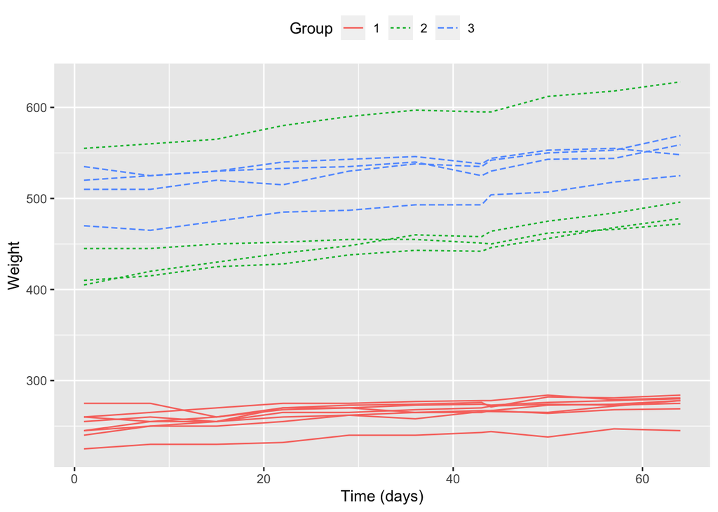

```r
ggplot(RATSL, aes(x = Time, y = Weight, group = interaction(Group, ID), colour = Group, linetype = Group)) +
  geom_line() +
  theme(legend.position = "top") +
  scale_y_continuous(limits = c(min(RATSL$Weight), max(RATSL$Weight))) +
  scale_x_continuous(name = "Time (days)", breaks = seq(0, 60, 20))
```

Let’s explore the data further by doing a few exercises, standardising the Weight variable and plotting again with the standardised variable.

```r
# Standardising the Weight variable and adding a column
RATSL <- RATSL %>%
  group_by(Time) %>%
  mutate(stdWeight = ((Weight-mean(Weight))/sd(Weight))) %>%
  ungroup()
# Glimpsing the data
glimpse(RATSL)
```

```
## Rows: 176
## Columns: 5
## $ ID        <fct> 1, 2, 3, 4, 5, 6, 7, 8, 9, 10, 11, 12, 13, 14, 15, 16, 1, 2,…
## $ Group     <fct> 1, 1, 1, 1, 1, 1, 1, 1, 2, 2, 2, 2, 3, 3, 3, 3, 1, 1, 1, 1, …
## $ Time      <int> 1, 1, 1, 1, 1, 1, 1, 1, 1, 1, 1, 1, 1, 1, 1, 1, 8, 8, 8, 8, …
## $ Weight    <int> 240, 225, 245, 260, 255, 260, 275, 245, 410, 405, 445, 555, …
## $ stdWeight <dbl> -1.0011429, -1.1203857, -0.9613953, -0.8421525, -0.8819001, …
```

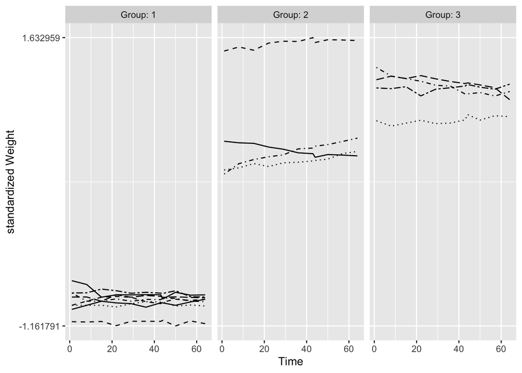

```r
# Plotting again with the standardised Weight variable
ggplot(RATSL, aes(x = Time, y = stdWeight, linetype = ID)) +
  geom_line() +
  scale_linetype_manual(values = rep(1:10, times=4)) +
  facet_grid(. ~ Group, labeller = label_both) +
  theme(legend.position = "none") +
  scale_y_continuous(name = "standardized Weight", (limits = c(min(RATSL$stdWeight), max(RATSL$stdWeight))))
```

The graph drawn with standardized weights shows quite clearly how the weights of the rats are placed in relation to the mean, but also, the relative development of individuals and groups. In group 1, the development seem to have been fairly even, the change is hardly visible. In group 2, individuals move in opposite directions. In group 3, weigths seem to be about steady or declining.

Caution should be taken in drawing far-reaching conclusions from this data, especially considering the small number of individuals included in groups 2 and 3.

Let’s move on to summary graphs.

```r
# Summary data with mean and standard error of RATS by treatment and week
RATSS <- RATSL %>%
  group_by(Group, Time) %>%
  summarise(mean = mean(Weight), se = (sd(Weight)/sqrt(length(unique(RATSL$ID))))) %>%
  ungroup()
# Glimpsing the data
glimpse(RATSS)
```

```
## Rows: 33
## Columns: 4
## $ Group <fct> 1, 1, 1, 1, 1, 1, 1, 1, 1, 1, 1, 2, 2, 2, 2, 2, 2, 2, 2, 2, 2, 2…
## $ Time  <int> 1, 8, 15, 22, 29, 36, 43, 44, 50, 57, 64, 1, 8, 15, 22, 29, 36, …
## $ mean  <dbl> 250.625, 255.000, 254.375, 261.875, 264.625, 265.000, 267.375, 2…
## $ se    <dbl> 3.805394, 3.273268, 2.868977, 3.400204, 2.764370, 2.945942, 2.73…
```

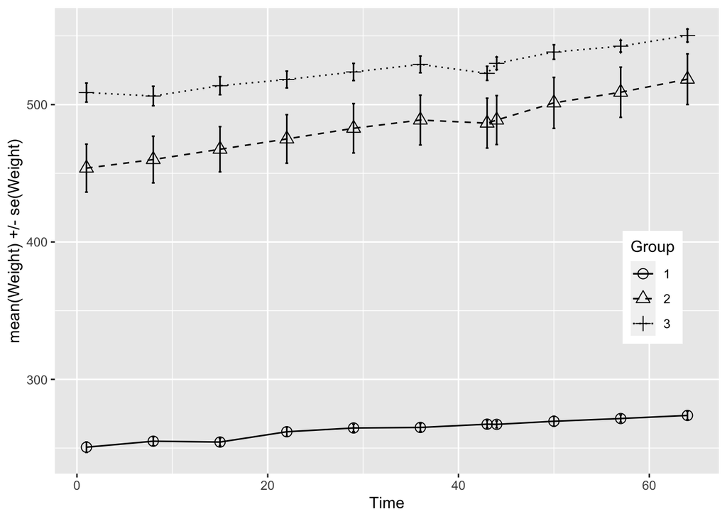

```r
# Plotting the mean profiles
ggplot(RATSS, aes(x = Time, y = mean, linetype = Group, shape = Group)) +
  geom_line() +
  scale_linetype_manual(values = c(1,2,3)) +
  geom_point(size=3) +
  scale_shape_manual(values = c(1,2,3)) +
  geom_errorbar(aes(ymin=mean-se, ymax=mean+se, linetype="1"), width=0.3) +
  theme(legend.position = c(0.9,0.4)) +
  scale_y_continuous(name = "mean(Weight) +/- se(Weight)")
```

Basically, the graph above shows that the variance in groups 1 and 3 is very small, and only slightly bigger in group 2. From the graph it would be roughly discernible that the weight is rising faster in group 2 than in groups 1 and 3.

We can also create boxplots in order to observe outliers and identify thresholds for filtration of outliers.

```r
# Create a summary data by Group and ID with mean as the summary variable (ignoring baseline Time 1).
RATSL8S <- RATSL %>%
  filter(Time > 1) %>%
  group_by(Group, ID) %>%
  summarise(mean=mean(Weight) ) %>%
  ungroup()
# Glimpsing the data
glimpse(RATSL8S)
```

```
## Rows: 16
## Columns: 3
## $ Group <fct> 1, 1, 1, 1, 1, 1, 1, 1, 2, 2, 2, 2, 3, 3, 3, 3
## $ ID    <fct> 1, 2, 3, 4, 5, 6, 7, 8, 9, 10, 11, 12, 13, 14, 15, 16
## $ mean  <dbl> 263.2, 238.9, 261.7, 267.2, 270.9, 276.2, 274.6, 267.5, 443.9, 4…
```

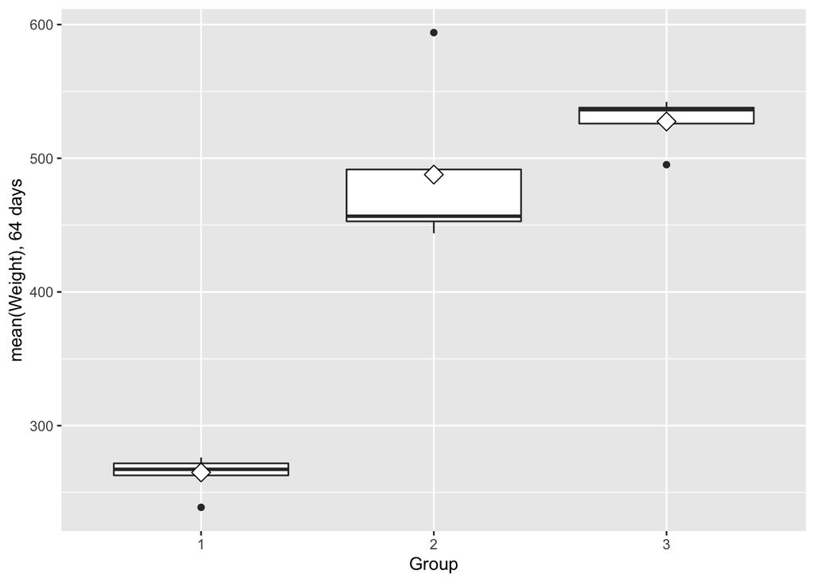

```r
# Drawing a boxplot of mean versus Group
ggplot(RATSL8S, aes(x = Group, y = mean)) +
  geom_boxplot() +
  stat_summary(fun = "mean", geom = "point", shape=23, size=4, fill = "white") +
  scale_y_continuous(name = "mean(Weight), 64 days")
```

If we are to follow the recipe of the Datacamp course and MABS book precisely, I would as my next step filter out the outlier values in order to plot the data again. I can do so by cutting off values below 250 grams and above 550 grams. However, getting rid of the outlier of group 3 will be trickier - I might have to filter out rats under 500 grams in that group only.

Again, I want to stress the small sample size, since this poses considerable problems for drawing conclusions. I would even be willing to pose some questions relating to the design of the original study Should for instance groups 2 and 3 have been combined, since the rats in these groups are considerably larger than in group 1 and since the groups taken together would be equally large as group 1? Or should the groups have been mixed, so that an equal number of small and large rats would have been given the same diet?

```r
# Filtering out outliers (rats weighting more than 550 and less than 250 grams)
RATSL8S1 <- RATSL8S %>% filter(RATSL8S$mean<550 & RATSL8S$mean > 250)
# Filtering the last outlier (in group 3, weighting less than 500 grams)
RATSL8S1 <- RATSL8S1[-which(RATSL8S1$Group == 3 & RATSL8S1$mean < 500),]
# Inspecting the summary reveals that one outlier has been eliminated in every group
summary(RATSL8S1)
```

```
##  Group       ID         mean
##  1:7   1      :1   Min.   :261.7
##  2:3   3      :1   1st Qu.:267.5
##  3:3   4      :1   Median :276.2
##        5      :1   Mean   :373.3
##        6      :1   3rd Qu.:457.5
##        7      :1   Max.   :542.2
##        (Other):7
```

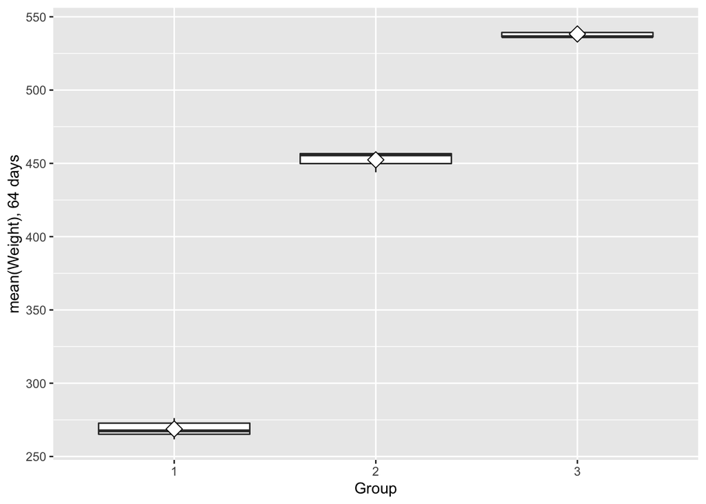

```r
# Plotting the data again without outliers
ggplot(RATSL8S1, aes(x = Group, y = mean)) +
  geom_boxplot() +
  stat_summary(fun = "mean", geom = "point", shape=23, size=4, fill = "white") +
  scale_y_continuous(name = "mean(Weight), 64 days")
```

```r
# Inspecting summaries by group
RATSL8S1 %>%
  group_by(Group) %>%
  summarize(mean = mean(mean))
```

```
## # A tibble: 3 × 2
##   Group  mean
##   <fct> <dbl>
## 1 1      269.
## 2 2      452.
## 3 3      538.
```

The plot drawn without outliers confirms largely what we knew from before: that group 1 consists of small rats, group 2 of mid-size and group 3 of large rats, weighting 269, 452 and 538 grams on average. The variance within groups is very small, partly due to the small sample size and the subsequent filtration of outliers.

Let’s do some calculations. Since I have three groups, I will not be performing simple t-tests between the groups since this could lead to the accumulation of type I errors. Instead, I’ll rely on ANOVA for testing.

```r
# Adding the baseline. According to the instructions on the Data camp course site,
# we should be using the original data as the source for the new variable.
# Since I never imported the original data, I now have to extract the baseline from
# the imported data. (I did confirm that the extracted vector corresponds to that from the original data.)
RATSL8S2 <- RATSL8S %>%
  mutate(baseline = RATSL[RATSL$Time == 1,]$Weight)

# Fit the linear model with the mean as the response
fit <- lm(mean ~ baseline + Group, data = RATSL8S2)

# A command used to prompt the use of zeros instead of scientific notation for p values
options(scipen=999)

# Compute the analysis of variance table for the fitted model with anova()
anova(fit)
```

```
## Analysis of Variance Table
##
## Response: mean
##           Df Sum Sq Mean Sq   F value             Pr(>F)
## baseline   1 253625  253625 1859.8201 0.0000000000000157 ***
## Group      2    879     439    3.2219            0.07586 .
## Residuals 12   1636     136
## ---
## Signif. codes:  0 '***' 0.001 '**' 0.01 '*' 0.05 '.' 0.1 ' ' 1
```

```r
# Print a summary of the regression model for comparison.
summary(fit)
```

```
##
## Call:
## lm(formula = mean ~ baseline + Group, data = RATSL8S2)
##
## Residuals:
##     Min      1Q  Median      3Q     Max
## -23.905  -4.194   2.190   7.577  14.800
##
## Coefficients:
##             Estimate Std. Error t value    Pr(>|t|)
## (Intercept) 33.16375   21.87657   1.516      0.1554
## baseline     0.92513    0.08572  10.793 0.000000156 ***
## Group2      34.85753   18.82308   1.852      0.0888 .
## Group3      23.67526   23.25324   1.018      0.3287
## ---
## Signif. codes:  0 '***' 0.001 '**' 0.01 '*' 0.05 '.' 0.1 ' ' 1
##
## Residual standard error: 11.68 on 12 degrees of freedom
## Multiple R-squared:  0.9936, Adjusted R-squared:  0.992
## F-statistic: 622.1 on 3 and 12 DF,  p-value: 0.0000000000001989
```

```r
# The confidence intervals (at 95 %) are given below.
confint(fit)
```

```
##                   2.5 %    97.5 %
## (Intercept) -14.5011937 80.828690
## baseline      0.7383656  1.111899
## Group2       -6.1544447 75.869498
## Group3      -26.9892106 74.339724
```

### Exploring the BPRS dataset

In the second part of the exercise we will be exploring the BPRS dataset using the techniques employed in Chapter 9 of the course book. Vehkalahti and Everitt (2019: 157) summarize the psychiatric study that provided the data for the dataset: “40 male subjects were randomly assigned to one of two treatment groups and each subject was rated on the brief psychiatric rating scale (BPRS) measured before treatment began (week 0) and then at weekly intervals for eight weeks. The BPRS assesses the level of 18 symptom constructs such as hostility, suspiciousness, hallucinations and grandiosity; each of these is rated from one (not present) to seven (extremely severe). The scale is used to evaluate patients suspected of having schizophrenia.”

Again, we will begin by reading the data, converting categorical variables to factors, exploring the structure of the data and plotting the data in order to explore patterns.

```r
# Reading the data
BPRSL <- read.csv("./data/bprsl.csv", stringsAsFactors = T)
# Converting categorical variables to factors
BPRSL$treatment <- as.factor(BPRSL$treatment)
BPRSL$subject <- as.factor(BPRSL$subject)
# Confirming the structure of the dataset
str(BPRSL)
```

```
## 'data.frame':    360 obs. of  4 variables:
##  $ treatment: Factor w/ 2 levels "1","2": 1 1 1 1 1 1 1 1 1 1 ...
##  $ subject  : Factor w/ 20 levels "1","2","3","4",..: 1 2 3 4 5 6 7 8 9 10 ...
##  $ week     : int  0 0 0 0 0 0 0 0 0 0 ...
##  $ bprs     : int  42 58 54 55 72 48 71 30 41 57 ...
```

```r
# Viewing the data
head(BPRSL)
```

```
##   treatment subject week bprs
## 1         1       1    0   42
## 2         1       2    0   58
## 3         1       3    0   54
## 4         1       4    0   55
## 5         1       5    0   72
## 6         1       6    0   48
```

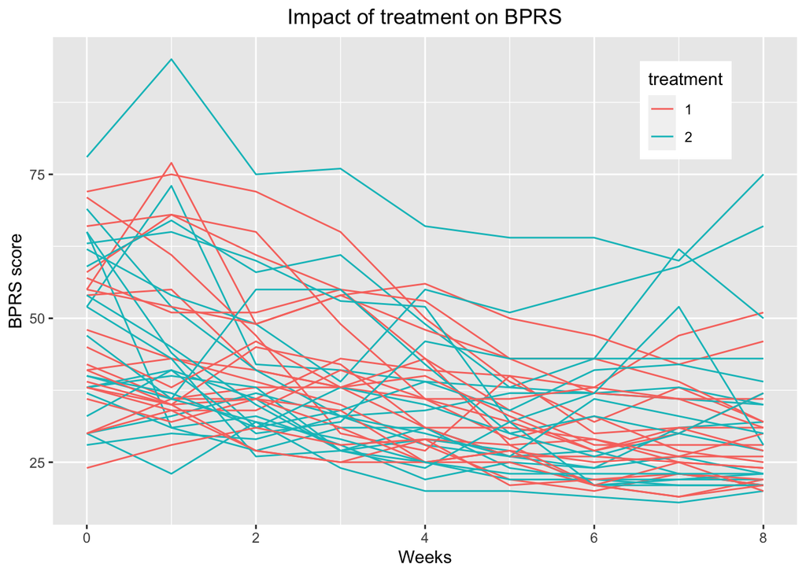

```r
# Plotting the BPRSL data
ggplot(BPRSL, aes(x = week, y = bprs, group = interaction(treatment, subject), inherit.aes = FALSE, colour = treatment)) +
  geom_line() +
  scale_x_continuous(name = "Weeks") +
  scale_y_continuous(name = "BPRS score") +
  theme(legend.position = c(0.85,0.85)) +
  ggtitle("Impact of treatment on BPRS") +
  theme(plot.title = element_text(hjust = 0.5))
```

From the plot above, it appears as if both treatments have a positive impact, generally lowering BPRS scores. However, simply by casting an eye on the chart it is hard to tell which treatment does a better job.

As a means of initial exploration, we can fit a linear regression model to try to understand the difference between the two models.

```r
# creating a regression model
BPRS_reg <- lm(bprs ~ week + treatment, data=BPRSL)
# printing out a summary of the model
summary(BPRS_reg)
```

```
##
## Call:
## lm(formula = bprs ~ week + treatment, data = BPRSL)
##
## Residuals:
##     Min      1Q  Median      3Q     Max
## -22.454  -8.965  -3.196   7.002  50.244
##
## Coefficients:
##             Estimate Std. Error t value            Pr(>|t|)
## (Intercept)  46.4539     1.3670  33.982 <0.0000000000000002 ***
## week         -2.2704     0.2524  -8.995 <0.0000000000000002 ***
## treatment2    0.5722     1.3034   0.439               0.661
## ---
## Signif. codes:  0 '***' 0.001 '**' 0.01 '*' 0.05 '.' 0.1 ' ' 1
##
## Residual standard error: 12.37 on 357 degrees of freedom
## Multiple R-squared:  0.1851, Adjusted R-squared:  0.1806
## F-statistic: 40.55 on 2 and 357 DF,  p-value: < 0.00000000000000022
```

From the summary of the regression model it can be seen that time (variable week) has a clearly significant impact. That is, the more weeks that pass, the lower the bprs score. However, we cannot find any difference between treatments, at least not when inspecting results using the regression model ignoring the repeated-measures structure.

Let’s move on to fit a random intercept model, which will allow the linear regression fit for each individual to differ in intercept from other individuals. We use the same explanatory variables: time (week) and treatment.

We will use the lme4 package, as instructed. The formula adheres to the basic linear regression formula standards, with the addition of random-effects terms distinguished by vertical bars (|).

```r
# accessing the lme4 library
library(lme4)
# creating a random intercept model
BPRS_ref <- lmer(bprs ~ week + treatment + (1 | subject), data = BPRSL, REML = FALSE)
# Printing the summary of the model
summary(BPRS_ref)
```

```
## Linear mixed model fit by maximum likelihood  ['lmerMod']
## Formula: bprs ~ week + treatment + (1 | subject)
##    Data: BPRSL
##
##      AIC      BIC   logLik deviance df.resid
##   2748.7   2768.1  -1369.4   2738.7      355
##
## Scaled residuals:
##     Min      1Q  Median      3Q     Max
## -3.0481 -0.6749 -0.1361  0.4813  3.4855
##
## Random effects:
##  Groups   Name        Variance Std.Dev.
##  subject  (Intercept)  47.41    6.885
##  Residual             104.21   10.208
## Number of obs: 360, groups:  subject, 20
##
## Fixed effects:
##             Estimate Std. Error t value
## (Intercept)  46.4539     1.9090  24.334
## week         -2.2704     0.2084 -10.896
## treatment2    0.5722     1.0761   0.532
##
## Correlation of Fixed Effects:
##            (Intr) week
## week       -0.437
## treatment2 -0.282  0.000
```

The printout contains a large number of interesting facts. Perhaps the most significant which I would like to pay attention to is the variability of the subjects’ scores, expressed by the standard deviation of 6.885 scores.

In the following, we can fit a random intercept and random slope model to the bprs data. This will allow the linear regression fits for each individual to differ in intercept and in slope, which will make it possible to account for the individual differences in the subjects’ developments and the effect of time.

```r
# creating a random intercept and random slope model
BPRS_ref1 <- lmer(bprs ~ week + treatment + (week | subject), data = BPRSL, REML = FALSE)
# printing a summary of the model
summary(BPRS_ref1)
```

```
## Linear mixed model fit by maximum likelihood  ['lmerMod']
## Formula: bprs ~ week + treatment + (week | subject)
##    Data: BPRSL
##
##      AIC      BIC   logLik deviance df.resid
##   2745.4   2772.6  -1365.7   2731.4      353
##
## Scaled residuals:
##     Min      1Q  Median      3Q     Max
## -2.8919 -0.6194 -0.0691  0.5531  3.7976
##
## Random effects:
##  Groups   Name        Variance Std.Dev. Corr
##  subject  (Intercept) 64.8222  8.0512
##           week         0.9609  0.9802   -0.51
##  Residual             97.4305  9.8707
## Number of obs: 360, groups:  subject, 20
##
## Fixed effects:
##             Estimate Std. Error t value
## (Intercept)  46.4539     2.1052  22.066
## week         -2.2704     0.2977  -7.626
## treatment2    0.5722     1.0405   0.550
##
## Correlation of Fixed Effects:
##            (Intr) week
## week       -0.582
## treatment2 -0.247  0.000
```

```r
# perform an ANOVA test on the two models
anova(BPRS_ref1, BPRS_ref)
```

```
## Data: BPRSL
## Models:
## BPRS_ref: bprs ~ week + treatment + (1 | subject)
## BPRS_ref1: bprs ~ week + treatment + (week | subject)
##           npar    AIC    BIC  logLik deviance  Chisq Df Pr(>Chisq)
## BPRS_ref     5 2748.7 2768.1 -1369.4   2738.7
## BPRS_ref1    7 2745.4 2772.6 -1365.7   2731.4 7.2721  2    0.02636 *
## ---
## Signif. codes:  0 '***' 0.001 '**' 0.01 '*' 0.05 '.' 0.1 ' ' 1
```

According to the printout of the random intercept and random slope model, the individual standard deviation has grown to over 8 now. The ANOVA test of the two models suggests that the random intercept and random slope model (BPRS_ref1) makes a better fit against the random intercept model (p = 0.026). Thus, the individual slopes seem to have an impact.

We can now fit a random intercept and slope model that allows for interaction between time and treatment.

```r
# creating a random intercept and random slope model with an interaction term
BPRS_ref2 <- lmer(bprs ~ week + treatment + (week | subject) + week*treatment, data = BPRSL, REML = FALSE)
# printing out a summary of the model
summary(BPRS_ref2)
```

```
## Linear mixed model fit by maximum likelihood  ['lmerMod']
## Formula: bprs ~ week + treatment + (week | subject) + week * treatment
##    Data: BPRSL
##
##      AIC      BIC   logLik deviance df.resid
##   2744.3   2775.4  -1364.1   2728.3      352
##
## Scaled residuals:
##     Min      1Q  Median      3Q     Max
## -3.0512 -0.6271 -0.0768  0.5288  3.9260
##
## Random effects:
##  Groups   Name        Variance Std.Dev. Corr
##  subject  (Intercept) 64.9964  8.0620
##           week         0.9687  0.9842   -0.51
##  Residual             96.4707  9.8220
## Number of obs: 360, groups:  subject, 20
##
## Fixed effects:
##                 Estimate Std. Error t value
## (Intercept)      47.8856     2.2521  21.262
## week             -2.6283     0.3589  -7.323
## treatment2       -2.2911     1.9090  -1.200
## week:treatment2   0.7158     0.4010   1.785
##
## Correlation of Fixed Effects:
##             (Intr) week   trtmn2
## week        -0.650
## treatment2  -0.424  0.469
## wek:trtmnt2  0.356 -0.559 -0.840
```

```r
# performing an ANOVA test on the two models
anova(BPRS_ref2, BPRS_ref1)
```

```
## Data: BPRSL
## Models:
## BPRS_ref1: bprs ~ week + treatment + (week | subject)
## BPRS_ref2: bprs ~ week + treatment + (week | subject) + week * treatment
##           npar    AIC    BIC  logLik deviance  Chisq Df Pr(>Chisq)
## BPRS_ref1    7 2745.4 2772.6 -1365.7   2731.4
## BPRS_ref2    8 2744.3 2775.4 -1364.1   2728.3 3.1712  1    0.07495 .
## ---
## Signif. codes:  0 '***' 0.001 '**' 0.01 '*' 0.05 '.' 0.1 ' ' 1
```

From the summary, it does not appear as if the interaction term would have any significant effect on the model as a whole (t value 1.785). Neither does treatment have any statistically significant impact (t value -1.2).

As a final step, we can reprint the original observed values study how they compare with the fitted values of the model. As it appears, the trend visible in the observed values is even more clearly visible in the model using the fitted values. I would conclude that time spent in care clearly has an effect on the brief psychiatric rating scale score measured among the 40 men here. Whether the decline is *due* to the treatment is unclear. From the data analysed here, it cannot be concluded that one treatment would be better than the other, or that the treatment would be effective in the first place. For us to be able to advance such a claim, we would have needed a control group receiving no treatment at all.

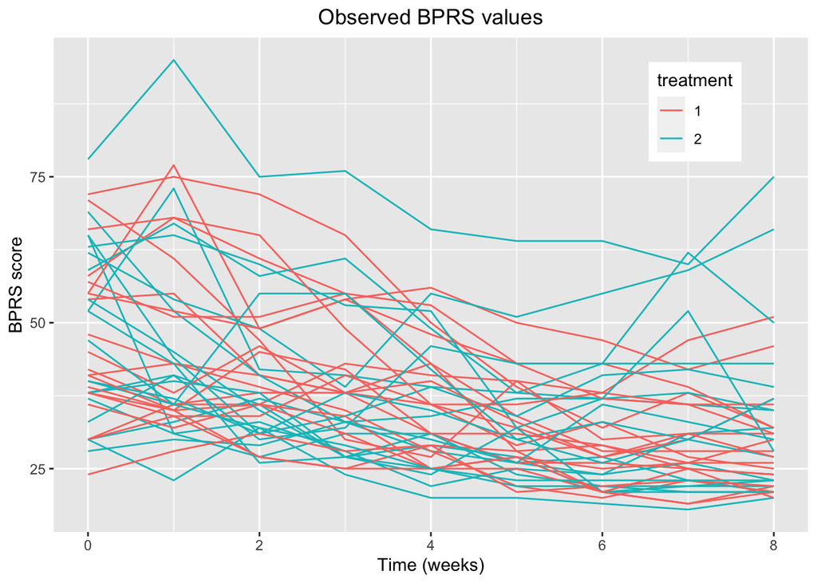

```r
# Creating a vector of the fitted values
fitted <- fitted(BPRS_ref2)
# Create a new column fitted to BPRSL
BPRSL <- mutate(BPRSL, fitted=fitted)
# Reprinting the plot with observed BPRS values (for the sake of comparison)
ggplot(BPRSL, aes(x = week, y = bprs, group = interaction(treatment, subject), colour = treatment)) +
  geom_line() +
  scale_x_continuous(name = "Time (weeks)") +
  scale_y_continuous(name = "BPRS score") +
  theme(legend.position = c(0.85,0.85)) +
  ggtitle("Observed BPRS values") +
  theme(plot.title = element_text(hjust = 0.5))
```

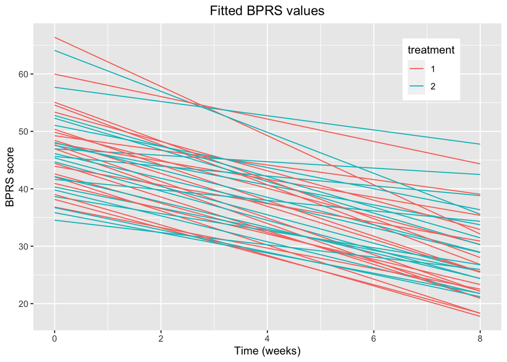

```r
# plotting the fitted values
ggplot(BPRSL, aes(x = week, y = fitted, group = interaction(treatment, subject), colour = treatment)) +
  geom_line() +
  scale_x_continuous(name = "Time (weeks)") +
  scale_y_continuous(name = "BPRS score") +
  theme(legend.position = c(0.85,0.85)) +
  ggtitle("Fitted BPRS values") +
  theme(plot.title = element_text(hjust = 0.5))
```